# **More classification**

SVM, kernels, classification metrics

[STOR 390](https://idc9.github.io/stor390/)

The [support vector machine](https://en.wikipedia.org/wiki/Support_vector_machine) (SVM) is one of the most popular and effective classification algorithms. Like [nearest centroid](https://idc9.github.io/stor390/notes/classification/classification.html), SVM is a linear classifier. Recall we were able to [turn linear regression into non-linear regression](https://idc9.github.io/stor390/notes/predictive_modeling/predictive_modeling.html) by explicitly adding more variables using non-linear variable transformations (e.g. polynomial terms). Similarly, we can turn a linear classier into a non-linear classifier by adding non-linear terms.

There is a way of automatically adding non-linear variables into a linear classifier by doing something called the [kernel trick](https://en.wikipedia.org/wiki/Kernel_method).

This lecture will cover

- maximal margin classifier (aka hard margin SVM)
- soft margin SVM
- Kernel SVM
- other classification metrics than just misclassification error

Hard margin SVM is useful to help understand soft margin SVM, but is not commonly used (although sometimes hard margin SVM works well for very high-dimensional data). These notes present the intuition behind soft margin SVM and point to reading for the mathematical details. Classification accuracy is an important metric, but there are other classification metrics you should be aware of.

```r
# this library implements SVM
library(e1071)

library(mvtnorm)
library(tidyverse)

# some helper functions I wrote
source('synthetic_distributions.R')
source('svm_fun.R')
```

# **Takeaway and Resources**

The point of this lecture is to introduce the intuitive ideas behind SVM and kernels and show you how to use them in R. The math underlying these algorithms is explained well in the resources listed below.

For more details see

- [Andrew Ng’s notes on SVM](http://cs229.stanford.edu/notes/cs229-notes3.pdf)
- [ISLR chapter 9](http://www-bcf.usc.edu/~gareth/ISL/) also [Elements of Statistical Learning chapter 12](http://statweb.stanford.edu/~tibs/ElemStatLearn/printings/ESLII_print10.pdf)
- [Foundations of Machine Learning chapter 4](http://www.cs.nyu.edu/~mohri/mlbook/) provides a clear explanation of the optimization problem and a theoretical perspective favored in the CS community (generalization bounds).

# **Maximal Margin**

The maximal margin (MM) classifier (also known as *hard margin support vector machine* assumes the two classes of data are [linearly separable](https://en.wikipedia.org/wiki/Linear_separability) i.e. we can draw a line where every data point in the first class is on one side and every point in the other class is on the other side of the line.

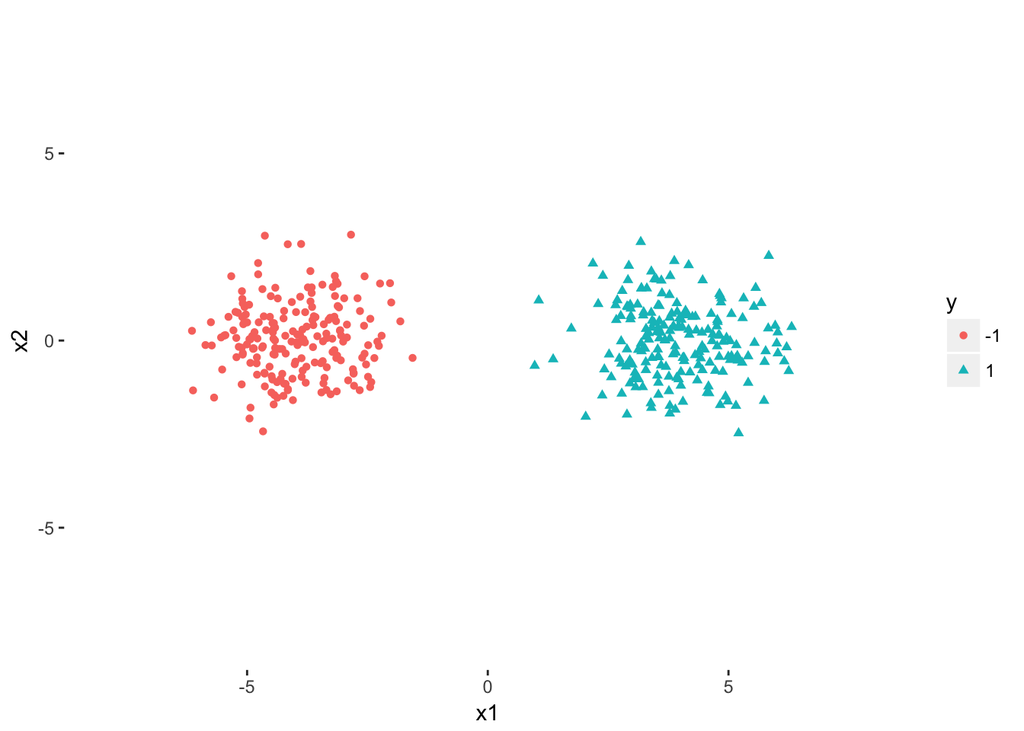

[Recall](https://idc9.github.io/stor390/notes/classification/classification.html#nc_is_a_linear_classifier) a linear classifier makes predictions by separating the data space into two regions by a hyperplane. When the data are two dimensional, as above, this means a linear classifier draws a line in the plane.

In the case the data are separable a reasonable aspiration is to have the separating hyperplane lie between the two classes i.e. one class is totally on one side of the hyperplane and the other class is totally on the other side. Suppose we call the distance between the hyperplane and the nearest data point the *margin*.

The MM hyperplane is allergic to data points; MM seeks to find the hyperplane that is furthest away from the nearest data point. In other words MM finds the hyperplane that maximizes the margin.

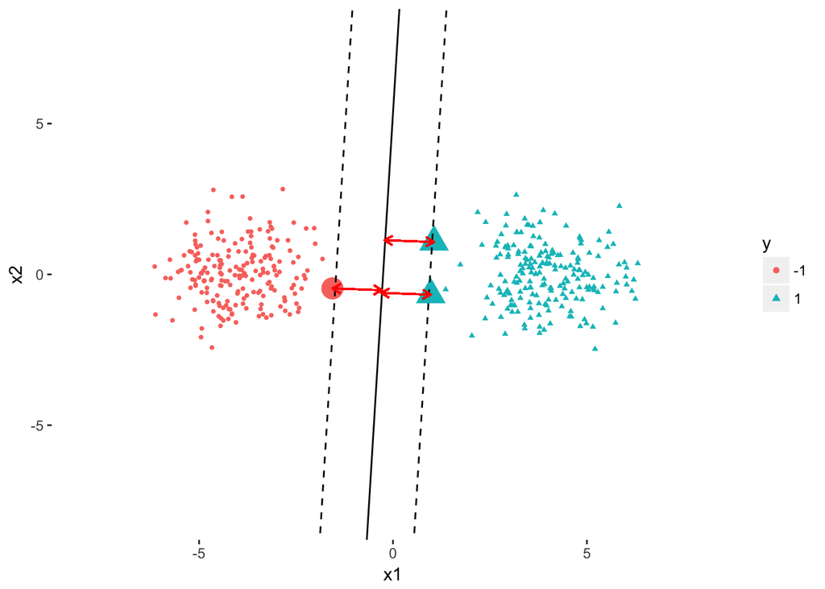

In the plot above the MM separating hyperplane is shown as the solid line. The red arrows show the margin width – the distance between the separating hyperplane and the nearest point. The dashed lines are the so called *marginal hyperplanes*. These marginal hyperplanes are parallel to the separating hyperplane. The highlighted points are called *support vectors* and are the points that are closest to the separating hyperplane (all three are equidistant to the separating hyperplane and lie on the marginal hyperplanes).

The support vectors play an important role in understanding MM and SVM in general. The MM normal vector and intercept depend only on the support vectors – none of the other data points. In contrast, nearest centroid depends on all the data points.

We can write the maximal margin classifier as an optimization problem: of all hyperplanes that separate the two classes, find the one that maximizes the margin. All of the aforementioned resources discuss how to write this as a math problem then solve the math problem.

# **Soft Margin Support Vector Machine**

Linear separability is a strong assumption that is typically not true for data sets; often the two classes cannot be separating by a hyperplane.

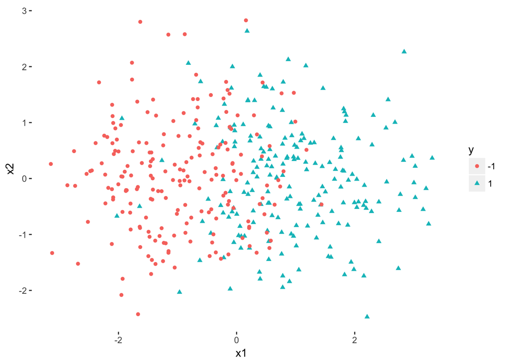

Soft margin [support vector machine](https://en.wikipedia.org/wiki/Support_vector_machine) (which we will call just SVM) is an adaptation of the maximal margin classifier that is cool with data points lying on the wrong side of the separating hyperplane.

Keep the following intuition in mind for this section. A good linear classifier should aim to put points

- on the correct side of the separating hyperplane far away from the separating hyperplane
- on the wrong side of the separating hyperplane close to the separating hyperplane

## Soft margin SVM (words)

Maximizing the margin is about putting points as far on the correct side of the separating hyperplane as possible. Soft margin SVM allows some “bad” points to be on the wrong side of the separating hyperplane, but penalizes these bad points. SVM then wants to put the remaining “good” points as far on the correct side of the margin as possible.

SVM thus has two competing objects: maximize the margin, but penalize disobedient points. SVM has a devil one on shoulder and angle on the other shoulder. Like many machine learning algorithms, SVM tries to strike a balance between two competing objectives.

In order to strike this balance between the two competing objectives, SVM comes with a tuning parameter, $C >0$. This tuning parameter, $C$, controls how much SVM cares about the “bad” points. When $C$ is large SVM tries very hard to put put every training point on the correct side of the separating hyperplane. When $C$ is small SVM has more chill about points being on the wrong side of the separating hyperplane.

All of the above mentioned resources discuss how to write this as a math problem then solve the math problem.

## Tuning SVM

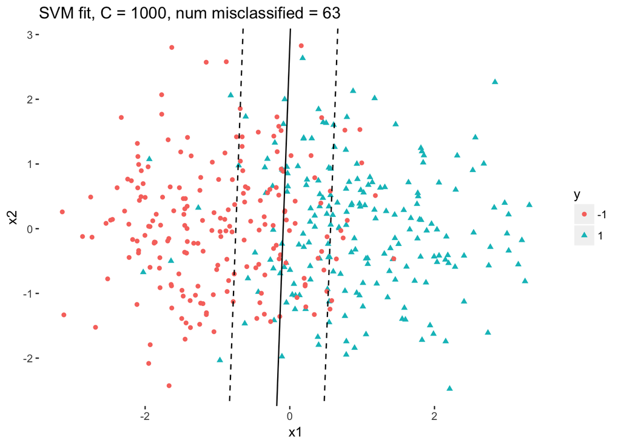

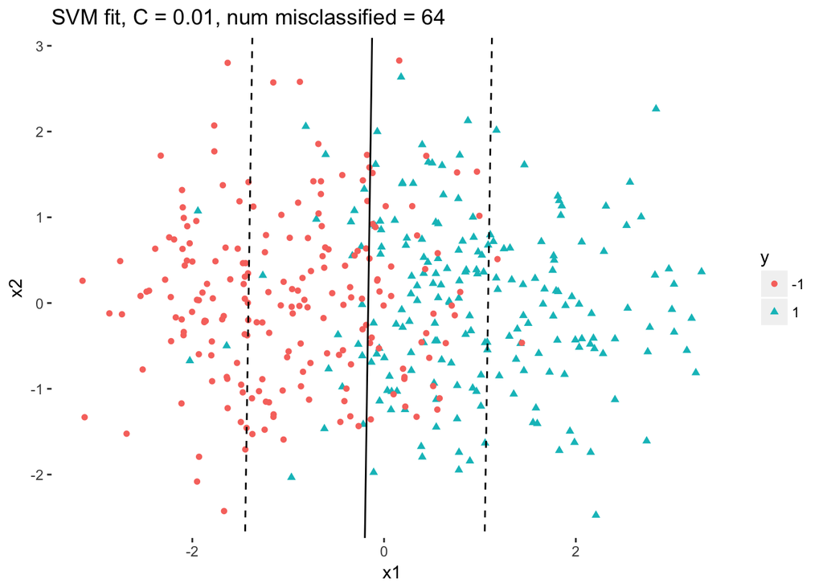

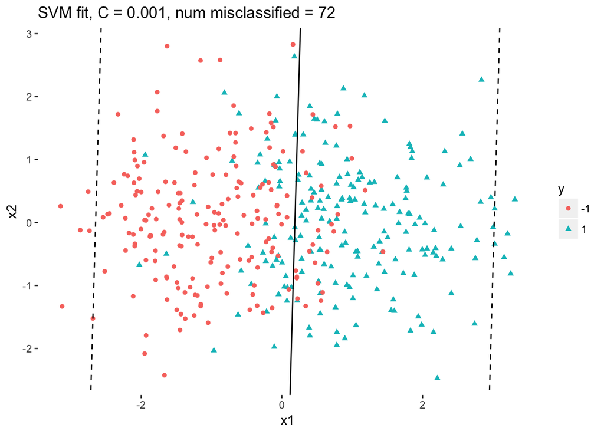

Notice that as $C$ decreases more points are misclassified. This is another example of the bais-variance tradeoff (recall chapter 2 from ISLR). Large values of $C$ make the classifier try really hard to not misclassify anyone – the so called low bias, high variance regime (leads to overfitting). Small values of $C$ are more ok with misclassified points – high bias, low variance. As with many things in life the key is to find the right balance.

The best value of $C$ is typically selected using [cross-validation](https://idc9.github.io/stor390/notes/cross_validation/cross_validation.html).